# Midterm Project Report

Paula Buitrago

03-12-2025

### Introduction:

For my midterm project, I chose to answer the question: *Do students with higher GPAs report experiencing more mental health issues like depression and anxiety?* I selected this topic because college plays a major role in mental health, and many students, including myself and my peers can relate to the stress and pressure that comes with academic performance. I was particularly interested in whether students who excel academically can also maintain good mental health, as this topic is not often talked about. Additionally, I hope this project raises awareness about mental health and encourages a healthier balance between academics and mental well-being.

To answer my research question, I used the *Student Mental Health* dataset by Shariful Islam, which I obtained through Kaggle. The dataset was collected through a survey conducted at the University of Malaysia and consists of 101 observations across 11 variables, such as gender, age, and major. I chose this dataset because it directly includes self-reported mental health indicators (depression and anxiety) as well as academic performance (GPA), making it highly relevant for analyzing the relationship between mental health and student achievement. For my analysis, I focused on three variables: depression, anxiety, and GPA. The depression and anxiety variables are represented as “Yes” or “No”, while GPA is categorized into ranges (2.50 - 2.99, 3.00 - 3.49, etc.).

```r
library(tidyverse)
df <- read_csv("Student Mental health.csv")
```

### Data analysis:

For this project, I performed descriptive analysis to examine the relationship between GPA and mental health variables (depression and anxiety). I renamed the three columns used to answer my question for clarity and to make the coding process easier. Then, I converted GPA from a character to a categorical variable. After this, I generated frequency tables for the depression and anxiety variables to analyze how many students in each GPA range reported experiencing these mental health issues. To visualize my findings, I generated bar plots, which helped me compare the distribution of depression and anxiety across the GPA categories.

```r
#to explore
dim(df)
```

```
## [1] 101  11
```

```r
str(df)
```

```
## spc_tbl_ [101 × 11] (S3: spec_tbl_df/tbl_df/tbl/data.frame)
##  $ Timestamp                                   : chr [1:101] "8/7/2020 12:02" "8/7/2020 12:04" "8/7/2020 12:05" "8/7/2020 12:06" ...
##  $ Choose your gender                          : chr [1:101] "Female" "Male" "Male" "Female" ...
##  $ Age                                         : num [1:101] 18 21 19 22 23 19 23 18 19 18 ...
##  $ What is your course?                        : chr [1:101] "Engineering" "Islamic education" "BIT" "Laws" ...
##  $ Your current year of Study                  : chr [1:101] "year 1" "year 2" "Year 1" "year 3" ...
##  $ What is your CGPA?                          : chr [1:101] "3.00 - 3.49" "3.00 - 3.49" "3.00 - 3.49" "3.00 - 3.49" ...
##  $ Marital status                              : chr [1:101] "No" "No" "No" "Yes" ...
##  $ Do you have Depression?                     : chr [1:101] "Yes" "No" "Yes" "Yes" ...
##  $ Do you have Anxiety?                        : chr [1:101] "No" "Yes" "Yes" "No" ...
##  $ Do you have Panic attack?                   : chr [1:101] "Yes" "No" "Yes" "No" ...
##  $ Did you seek any specialist for a treatment?: chr [1:101] "No" "No" "No" "No" ...
##  - attr(*, "spec")=
##   .. cols(
##   ..   Timestamp = col_character(),
##   ..   `Choose your gender` = col_character(),
##   ..   Age = col_double(),
##   ..   `What is your course?` = col_character(),
##   ..   `Your current year of Study` = col_character(),
##   ..   `What is your CGPA?` = col_character(),
##   ..   `Marital status` = col_character(),
##   ..   `Do you have Depression?` = col_character(),
##   ..   `Do you have Anxiety?` = col_character(),
##   ..   `Do you have Panic attack?` = col_character(),
##   ..   `Did you seek any specialist for a treatment?` = col_character()
##   .. )
##  - attr(*, "problems")=<externalptr>
```

```r
head(df)
```

```
## # A tibble: 6 × 11
##   Timestamp      `Choose your gender`   Age `What is your course?`
##   <chr>          <chr>                <dbl> <chr>
## 1 8/7/2020 12:02 Female                  18 Engineering
## 2 8/7/2020 12:04 Male                    21 Islamic education
## 3 8/7/2020 12:05 Male                    19 BIT
## 4 8/7/2020 12:06 Female                  22 Laws
## 5 8/7/2020 12:13 Male                    23 Mathemathics
## 6 8/7/2020 12:31 Male                    19 Engineering
## # ℹ 7 more variables: `Your current year of Study` <chr>,
## #   `What is your CGPA?` <chr>, `Marital status` <chr>,
## #   `Do you have Depression?` <chr>, `Do you have Anxiety?` <chr>,
## #   `Do you have Panic attack?` <chr>,
## #   `Did you seek any specialist for a treatment?` <chr>
```

```r
tail(df)
```

```
## # A tibble: 6 × 11
##   Timestamp           `Choose your gender`   Age `What is your course?`
##   <chr>               <chr>                <dbl> <chr>
## 1 13/07/2020 19:08:32 Female                  18 Islamic Education
## 2 13/07/2020 19:56:49 Female                  21 BCS
## 3 13/07/2020 21:21:42 Male                    18 Engineering
## 4 13/07/2020 21:22:56 Female                  19 Nursing
## 5 13/07/2020 21:23:57 Female                  23 Pendidikan Islam
## 6 18/07/2020 20:16:21 Male                    20 Biomedical science
## # ℹ 7 more variables: `Your current year of Study` <chr>,
## #   `What is your CGPA?` <chr>, `Marital status` <chr>,
## #   `Do you have Depression?` <chr>, `Do you have Anxiety?` <chr>,
## #   `Do you have Panic attack?` <chr>,
## #   `Did you seek any specialist for a treatment?` <chr>
```

```r
sum(is.na(df))
```

```
## [1] 1
```

```r
summary(df)
```

```
##   Timestamp         Choose your gender      Age        What is your course?
##  Length:101         Length:101         Min.   :18.00   Length:101
##  Class :character   Class :character   1st Qu.:18.00   Class :character
##  Mode  :character   Mode  :character   Median :19.00   Mode  :character
##                                        Mean   :20.53
##                                        3rd Qu.:23.00
##                                        Max.   :24.00
##                                        NA's   :1
##  Your current year of Study What is your CGPA? Marital status
##  Length:101                 Length:101         Length:101
##  Class :character           Class :character   Class :character
##  Mode  :character           Mode  :character   Mode  :character
##
##
##
##
##  Do you have Depression? Do you have Anxiety? Do you have Panic attack?
##  Length:101              Length:101           Length:101
##  Class :character        Class :character     Class :character
##  Mode  :character        Mode  :character     Mode  :character
##
##
##
##
##  Did you seek any specialist for a treatment?
##  Length:101
##  Class :character
##  Mode  :character
##
##
##
##
```

```r
df <- df |>
  rename("depression" = "Do you have Depression?", "anxiety" = "Do you have Anxiety?", "gpa" = "What is your CGPA?")
df
```

```
## # A tibble: 101 × 11
##    Timestamp      `Choose your gender`   Age `What is your course?`
##    <chr>          <chr>                <dbl> <chr>
##  1 8/7/2020 12:02 Female                  18 Engineering
##  2 8/7/2020 12:04 Male                    21 Islamic education
##  3 8/7/2020 12:05 Male                    19 BIT
##  4 8/7/2020 12:06 Female                  22 Laws
##  5 8/7/2020 12:13 Male                    23 Mathemathics
##  6 8/7/2020 12:31 Male                    19 Engineering
##  7 8/7/2020 12:32 Female                  23 Pendidikan islam
##  8 8/7/2020 12:33 Female                  18 BCS
##  9 8/7/2020 12:35 Female                  19 Human Resources
## 10 8/7/2020 12:39 Male                    18 Irkhs
## # ℹ 91 more rows
## # ℹ 7 more variables: `Your current year of Study` <chr>, gpa <chr>,
## #   `Marital status` <chr>, depression <chr>, anxiety <chr>,
## #   `Do you have Panic attack?` <chr>,
## #   `Did you seek any specialist for a treatment?` <chr>
```

```r
df$gpa <- as.factor(df$gpa)

str(df)
```

```
## spc_tbl_ [101 × 11] (S3: spec_tbl_df/tbl_df/tbl/data.frame)
##  $ Timestamp                                   : chr [1:101] "8/7/2020 12:02" "8/7/2020 12:04" "8/7/2020 12:05" "8/7/2020 12:06" ...
##  $ Choose your gender                          : chr [1:101] "Female" "Male" "Male" "Female" ...
##  $ Age                                         : num [1:101] 18 21 19 22 23 19 23 18 19 18 ...
##  $ What is your course?                        : chr [1:101] "Engineering" "Islamic education" "BIT" "Laws" ...
##  $ Your current year of Study                  : chr [1:101] "year 1" "year 2" "Year 1" "year 3" ...
##  $ gpa                                         : Factor w/ 5 levels "0 - 1.99","2.00 - 2.49",..: 4 4 4 4 4 5 5 5 3 5 ...
##  $ Marital status                              : chr [1:101] "No" "No" "No" "Yes" ...
##  $ depression                                  : chr [1:101] "Yes" "No" "Yes" "Yes" ...
##  $ anxiety                                     : chr [1:101] "No" "Yes" "Yes" "No" ...
##  $ Do you have Panic attack?                   : chr [1:101] "Yes" "No" "Yes" "No" ...
##  $ Did you seek any specialist for a treatment?: chr [1:101] "No" "No" "No" "No" ...
##  - attr(*, "spec")=
##   .. cols(
##   ..   Timestamp = col_character(),
##   ..   `Choose your gender` = col_character(),
##   ..   Age = col_double(),
##   ..   `What is your course?` = col_character(),
##   ..   `Your current year of Study` = col_character(),
##   ..   `What is your CGPA?` = col_character(),
##   ..   `Marital status` = col_character(),
##   ..   `Do you have Depression?` = col_character(),
##   ..   `Do you have Anxiety?` = col_character(),
##   ..   `Do you have Panic attack?` = col_character(),
##   ..   `Did you seek any specialist for a treatment?` = col_character()
##   .. )
##  - attr(*, "problems")=<externalptr>
```

```r
tab <- table(df$gpa, df$depression)
tab
```

```
##
##               No Yes
##   0 - 1.99     4   0
##   2.00 - 2.49  2   0
##   2.50 - 2.99  1   3
##   3.00 - 3.49 24  19
##   3.50 - 4.00 35  13
```

```r
tab2 <- table(df$gpa, df$anxiety)
tab2
```

```
##
##               No Yes
##   0 - 1.99     4   0
##   2.00 - 2.49  2   0
##   2.50 - 2.99  3   1
##   3.00 - 3.49 28  15
##   3.50 - 4.00 30  18
```

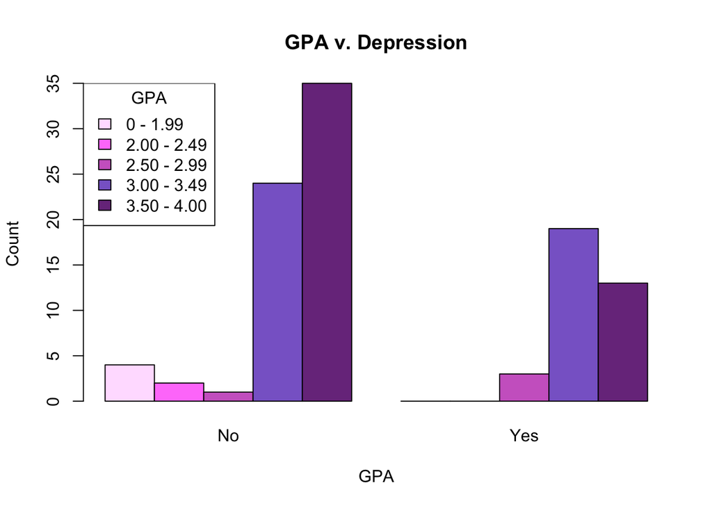

```r
df_col<- c("thistle1", "orchid1", "orchid3","mediumpurple3", "mediumorchid4")

barplot(tab, beside = TRUE, col = df_col,
        main = "GPA v. Depression",
        xlab = "GPA",
        ylab = "Count")

legend("topleft", legend = rownames(tab), fill = df_col, title = "GPA", horiz = FALSE)
```

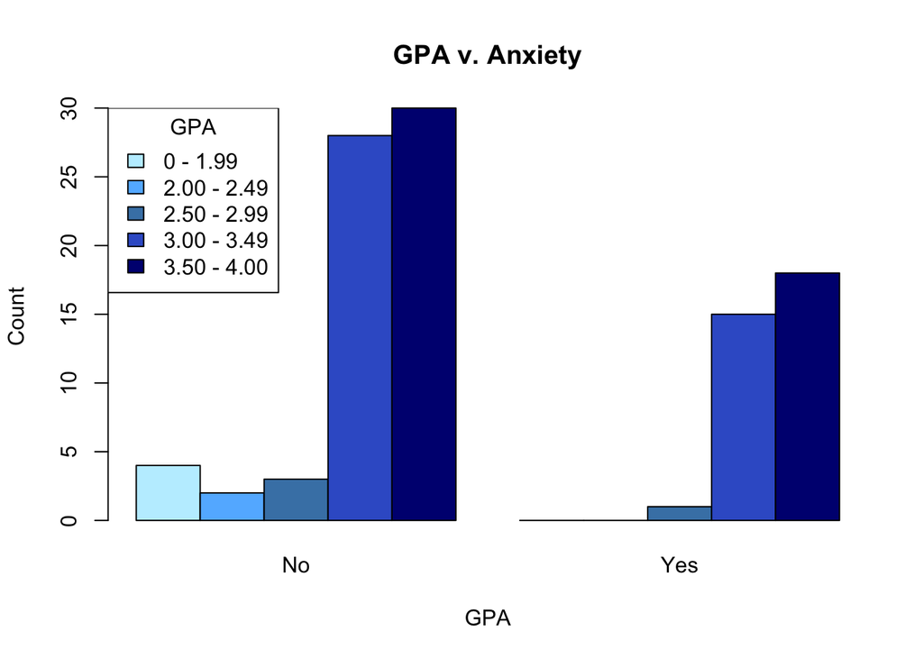

```r
df_col<- c("lightblue1", "steelblue1", "steelblue","royalblue3", "navy")

bp <- barplot(tab2, beside = TRUE, col = df_col,
        main = "GPA v. Anxiety",
        xlab = "GPA",
        ylab = "Count")

legend("topleft", legend = rownames(tab2), fill = df_col, title = "GPA", horiz = FALSE)
```

### References:

Islam, Shariful. (2021). *Student Mental Health Dataset*. https://www.kaggle.com/datasets/shariful07/student-mental-health. Accessed March 2, 2025.